# Endogenous RNA mass

Franco Poma

2025-02-11

# Load libraries

```r
library(dplyr)
library(tidyverse)
require(readr)
library(DT)
library(ggplot2)
library(stringr)
require(ggbeeswarm)
color_panel<-c("#e35d6a","#428bca","darkgray","#e87810","#5bb75b", "#23496b","#ffbf00","#cc2028","#039748","pink","gray")
theme_final<- theme(axis.text.x=element_blank(), axis.text.y=element_text(size=8),axis.title.x = element_blank(), axis.title.y = element_text(size=8),plot.title = element_text(hjust = 0.5, size = 8))
data_dir <- "./Data"
```

# Make annotation only Nash subcohort

```r
#Load outliers
outliers_df<-read.table(paste0(data_dir, "/OutliersC2.txt"), header = T) # set of 41 outliers.
#Annotation
ann<-read_tsv(paste0(data_dir, "/Annotation_Cohort2.tsv"))
#Select only NASH cohort and baseline samples
pDat_NASH<- ann %>% filter(str_detect(Cohort, "NASH"))
pDat_NASH <- pDat_NASH %>% dplyr::filter(Visit_Type=="Baseline")

#Removing NoNAFLD samples
pDat_NASH <- pDat_NASH %>% dplyr::filter(NASH!="No NAFLD")
colnames(pDat_NASH)[1]<-"RNAID"
#Removing Outliers
pDat_NASH<-pDat_NASH %>% dplyr::filter(!RNAID%in%outliers_df$RNAID)
#New varaible NASH_risk
pDat_NASH <- pDat_NASH %>%  mutate("Risk" = as.factor(if_else(pDat_NASH$NASH=="NASH"&pDat_NASH$Fibrosis%in%c("F2","F3", "F4", "F5", "F6"), "Risk", "No_Risk")))
pDat_NASH$Fibrosis <- factor(pDat_NASH$Fibrosis, levels = c("F0", "F1", "F2", "F3", "F4"))
```

# Load counts

```r
htseq <- read_delim(paste0(data_dir, "/htseq_cohort2.txt"))
#remove ambiguous, not unique, no feature
htseq <- htseq %>% filter(!str_detect(ensembl_gene_id, "^__"))
#Select only Nash cohort counts
htseq <- htseq  %>%
  column_to_rownames("ensembl_gene_id")

count_table_NASH <- htseq %>% dplyr::select(pDat_NASH$RNAID)

count_table_NASH <- count_table_NASH  %>%
  rownames_to_column("ensembl_gene_id")
```

# RNA concentration

### Step 1: Calculate the Diluted Concentration of the Spike-In

If the stock concentration is $C_{\text{stock}}$ (in attomol/μL) and the dilution factor is $D$, the diluted concentration is:
$$C_{\text{diluted}} = \frac{C_{\text{stock}}}{D}$$

### Step 2: Calculate Total Moles Added to the Lysis Buffer

Given a volume $V_{\text{added}}$ (in μL) of the diluted spike-in solution:
$$n_{\text{total}} = C_{\text{diluted}} \times V_{\text{added}} \times
10^{-18} \quad \text{(moles)}$$
*Note:* The factor $10^{-18}$ converts attomol to mol.

### Step 3: Adjust for the Volume Transferred During Purification

If the total lysis buffer volume is $V_{\text{lysis}}$ (μL) and the volume transferred is $V_{\text{transferred}}$ (μL), then the moles in the transferred volume are:
$$n_{\text{transferred}} = n_{\text{total}} \times
\frac{V_{\text{transferred}}}{V_{\text{lysis}}}$$

### Step 4: Calculate the Molecular Weight of the Spike-In RNA

For an RNA molecule of length $L$ nucleotides, its molecular weight is:
$$MW = (L \times 321.47\ \text{g/mol}) + 18.02\ \text{g/mol}$$

### Step 5: Calculate the Mass of the Spike-In

The mass (in grams) of the spike-in in the transferred volume is:
$$\text{Mass}_{\text{spike}} = n_{\text{transferred}} \times MW$$
To convert this mass to nanograms (ng):
$$\text{Mass}_{\text{spike}}\, (\text{ng}) = n_{\text{transferred}} \times
MW \times 10^9$$

### Step 6: Estimate the Mass of Endogenous RNA

```r
#Keep only sequin spikes
Spikes_counts <- filter(count_table_NASH, str_detect(ensembl_gene_id,"R1|R2"))

## get most abundant spike
Spikes_counts$Total <- rowSums(Spikes_counts[2:175])
Top_Spike<-Spikes_counts[order(Spikes_counts$Total, decreasing=T),][1,]
rownames(Top_Spike)<-NULL
Top_Spike <- Top_Spike[,1:ncol(Top_Spike)-1]
Top_Spike <- Top_Spike %>% column_to_rownames(var = "ensembl_gene_id")
Top_Spike_name <- rownames(Top_Spike)[1]
print (paste0("Top Spike is: ", Top_Spike_name))
```

```
## [1] "Top Spike is: R2_65"
```

```r
Top_Spike <- as.data.frame(t(Top_Spike))
Top_Spike <- Top_Spike %>% rownames_to_column(var="RNAID")

# Load spike counts and merge
Spikes_C2<- read.csv(paste0(data_dir, "/SpikeRatio_C2.csv"))


Top_Spike <- left_join(Top_Spike, Spikes_C2)

#load sum of endogenous from previous analysis
Spikes_C1<- read.csv(paste0(data_dir, "/SpikeRatio_C1.csv"))
Spikes_C2<- read.csv(paste0(data_dir, "/SpikeRatio_C2.csv"))
#Top spike is R2_65
#concentration attom/ul got from provider
spike_stock<-966.797
#length (nt)
spike_len<-908
#Sequin mix vol added to lysis buffer (ul)
spike_vol<-8.75
dilution <- 1/3000
#Lysis Buffer Volume ul
LysisVol_initial<-2500
LysisVol_Final<-2000

#moles of sequin R2_65 in 8.75ul
spike_moles <- spike_stock*dilution*spike_vol*10^-18
#Moles transferred to final mix
spike_moles_final <- spike_moles *(LysisVol_Final/LysisVol_initial)

#Molecular weight of spike (g/mol) - standard formula to calculate weight of a single stranded RNA molecule
spike_mw <- (spike_len * 321.47) + 18.02
#Spike mass (g) added to the mix
spike_mass <- spike_moles_final * spike_mw
#Spike mass in nanograms
spike_mass_ng <- spike_mass * 10^9
#endogenous RNA mass(ng) in 2000ul
Top_Spike <- Top_Spike %>% mutate(Endo_mass=spike_mass_ng*endogenous/R2_65)
#endogenous RNA concentration per ml
Top_Spike <- left_join(Top_Spike, pDat_NASH, by="RNAID")
Top_Spike$Plasma_input_vol_ul  <- if_else(Top_Spike$`QC_Plasma_input_volume_(µl)` == "less than 2 ml", 1990, as.numeric(Top_Spike$`QC_Plasma_input_volume_(µl)`))
Top_Spike <- Top_Spike %>% mutate(Endo_conc=Endo_mass/Plasma_input_vol_ul)
datatable(Top_Spike)
```

|  | RNAID | R2_65 | endogenous | ERCC | Sequin | ERCCvsSequin | EndovsSeq | EndovsERCC | Endo_mass | PlasmaID | Subject_ID | Visit_Type | Visit_Date | Hospital | Cohort | Sex | NASH | Fibrosis | Cirrhosis | QC_defrosting_temp | QC_Plasma_input_volume_(µl) | Risk | Plasma_input_vol_ul | Endo_conc |
| --- | --- | --- | --- | --- | --- | --- | --- | --- | --- | --- | --- | --- | --- | --- | --- | --- | --- | --- | --- | --- | --- | --- | --- | --- |
| 1 | RNA023479 | 21193 | 1621166 | 120 | 131983 | 0.000909208004061129 | 12.2831425259314 | 13509.7166666667 | 0.05037328077690913 | PLA00001A | A010001 | Baseline | 2020-02-28T00:00:00Z | Antwerp | NASH biomarker | Male | NAFL | F0 | No | RT | 2000 | No_Risk | 2000 | 2.518664038845456e-05 |
| 2 | RNA023491 | 19832 | 698922 | 74 | 118605 | 0.000623919733569411 | 5.89285443278108 | 9444.89189189189 | 0.02320744797454608 | PLA00002A | A010002 | Baseline | 2020-03-17T00:00:00Z | Antwerp | NASH biomarker,HCC prognostic marker | Female | NASH | F2 | No | RT | 2000 | Risk | 2000 | 1.160372398727304e-05 |
| 3 | RNA023425 | 14999 | 382797 | 79 | 84508 | 0.000934822738675628 | 4.52971316325082 | 4845.53164556962 | 0.01680627279862176 | PLA00003L | L010158 | Baseline | 2021-02-16T00:00:00Z | Leuven | NASH biomarker,HCC prognostic marker | Male | NASH | F4 | Yes | RT | 2000 | Risk | 2000 | 8.403136399310882e-06 |
| 4 | RNA023403 | 11601 | 672191 | 116 | 66026 | 0.00175688365189471 | 10.1807015418169 | 5794.75 | 0.03815596615559633 | PLA00005L | L010103 | Baseline | 2020-02-04T00:00:00Z | Leuven | NASH biomarker | Male | NASH | F3 | No | RT | 2000 | Risk | 2000 | 1.907798307779816e-05 |
| 5 | RNA022818 | 28434 | 1026394 | 137 | 165553 | 0.000827529552469602 | 6.19979100348529 | 7491.92700729927 | 0.02377066512410584 | PLA00010G | G010010 | Baseline | 2020-01-30T00:00:00Z | Ghent | NASH biomarker | Female | NASH | F1 | No | ice | 2000 | No_Risk | 2000 | 1.188533256205292e-05 |
| 6 | RNA023504 | 41878 | 1241841 | 178 | 238015 | 0.000747852026132807 | 5.21749049429658 | 6976.63483146067 | 0.01952743720645914 | PLA00012A | A010012 | Baseline | 2020-06-02T00:00:00Z | Antwerp | NASH biomarker,HCC prognostic marker | Male | NASH | F4 | Yes | RT | 2000 | Risk | 2000 | 9.763718603229569e-06 |
| 7 | RNA022822 | 39996 | 994415 | 124 | 230463 | 0.0005380473221298 | 4.314857482546 | 8019.47580645161 | 0.01637254886507787 | PLA00012G | G010012 | Baseline | 2020-02-06T00:00:00Z | Ghent | NASH biomarker | Male | NAFL | F1 | No | ice | 2000 | No_Risk | 2000 | 8.186274432538933e-06 |
| 8 | RNA023506 | 33367 | 773164 | 125 | 185870 | 0.000672513046753107 | 4.15970301823855 | 6185.312 | 0.01525877437021955 | PLA00013A | A010013 | Baseline | 2020-06-03T00:00:00Z | Antwerp | NASH biomarker,HCC prognostic marker | Male | NASH | F4 | Yes | RT | 2000 | Risk | 2000 | 7.629387185109775e-06 |
| 9 | RNA023407 | 25121 | 1536648 | 111 | 154025 | 0.000720662230157442 | 9.97661418600877 | 13843.6756756757 | 0.04028122410420261 | PLA00014L | L010110 | Baseline | 2020-02-25T00:00:00Z | Leuven | NASH biomarker,HCC prognostic marker | Male | NASH | F2 | No | RT | 2000 | Risk | 2000 | 2.014061205210131e-05 |
| 10 | RNA022824 | 40783 | 1718697 | 76 | 247098 | 0.000307570275761034 | 6.95552776631134 | 22614.4342105263 | 0.02775142815485587 | PLA00016G | G010016 | Baseline | 2020-08-18T00:00:00Z | Ghent | NASH biomarker,HCC prognostic marker | Female | NASH | F3 | No | ice | 2000 | Risk | 2000 | 1.387571407742793e-05 |

[output cut: 164 more lines]

# Statistical Analysis

## Distribution of endogenous RNA concentration

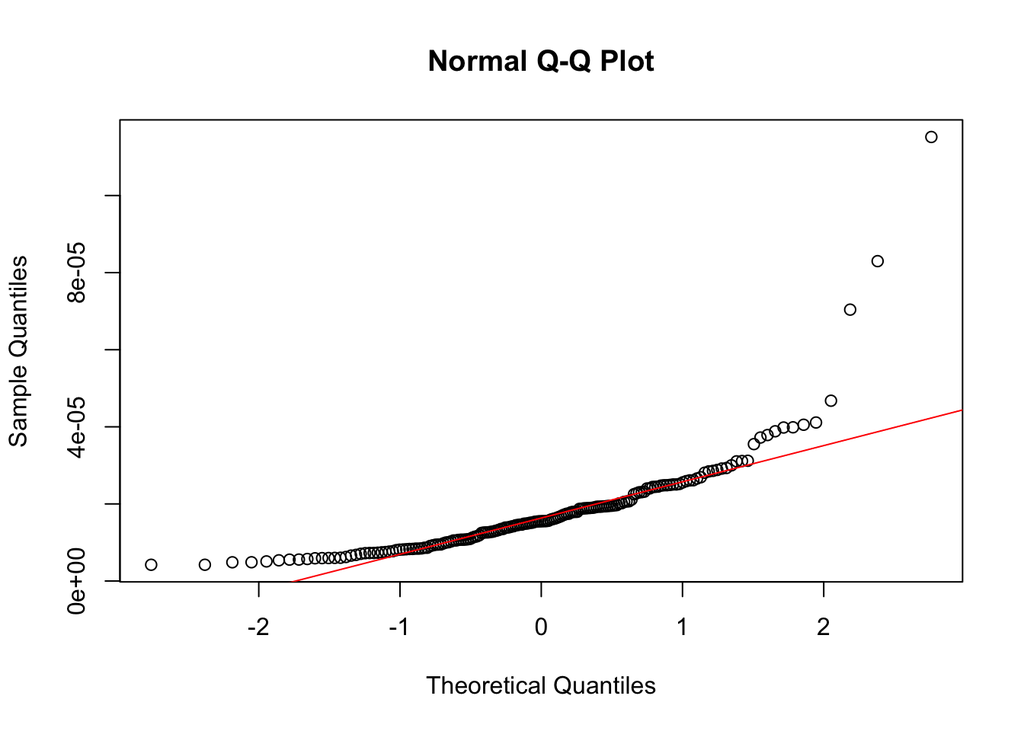

```r
# png("qqplot_NashRisk.png", width = 800, height = 600)
qqnorm(Top_Spike$Endo_conc)
qqline(Top_Spike$Endo_conc, col = "red")
```

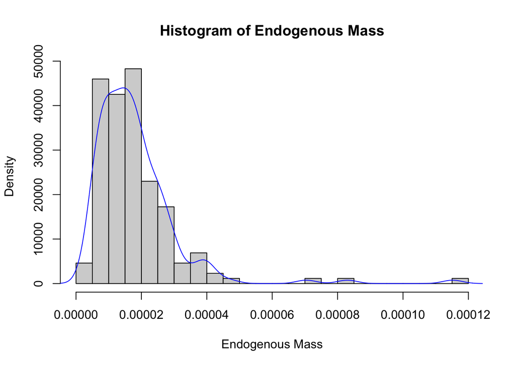

```r
hist(Top_Spike$Endo_conc, breaks = 20, probability = TRUE,
     main = "Histogram of Endogenous Mass", xlab = "Endogenous Mass")
lines(density(Top_Spike$Endo_conc), col = "blue")
```

#### Nash Risk

Taking into account Hospital as batch effect

```r
#install.packages("coin")
library(coin)

Top_Spike$Hospital <- as.factor(Top_Spike$Hospital)
coin::wilcox_test(Endo_conc ~ Risk | Hospital, data = Top_Spike,
            distribution = "exact")
```

```
##
##  Exact Wilcoxon-Mann-Whitney Test
##
## data:  Endo_conc by
##   Risk (No_Risk, Risk)
##   stratified by Hospital
## Z = 1.1625, p-value = 0.2462
## alternative hypothesis: true mu is not equal to 0
```

Without hospital

```r
coin::wilcox_test(Endo_conc ~ Risk, data = Top_Spike)
```

```
##
##  Asymptotic Wilcoxon-Mann-Whitney Test
##
## data:  Endo_conc by Risk (No_Risk, Risk)
## Z = 1.7067, p-value = 0.08787
## alternative hypothesis: true mu is not equal to 0
```

No significant differences between Nash Risk groups.

#### Fibrosis

Taking into account Hospital as batch effect

```r
data <- Top_Spike %>% dplyr::filter(Fibrosis%in% c("F0", "F4"))%>%
  droplevels()
coin::wilcox_test(Endo_conc ~ Fibrosis | Hospital, data = data,
            distribution = "exact")
```

```
##
##  Exact Wilcoxon-Mann-Whitney Test
##
## data:  Endo_conc by
##   Fibrosis (F0, F4)
##   stratified by Hospital
## Z = 3.121, p-value = 0.00148
## alternative hypothesis: true mu is not equal to 0
```

Without hospital

```r
coin::wilcox_test(Endo_conc ~ Fibrosis, data = data)
```

```
##
##  Asymptotic Wilcoxon-Mann-Whitney Test
##
## data:  Endo_conc by Fibrosis (F0, F4)
## Z = 3.6873, p-value = 0.0002266
## alternative hypothesis: true mu is not equal to 0
```

Both tests show a significant difference in the endogenous RNA concentration between Fibrosis F0 and F4 groups.

```r
res_df <- data %>% dplyr::group_by(Fibrosis) %>% summarise(mean= sprintf("%.2e", mean(Endo_conc)), sd= sprintf("%.2e", sd(Endo_conc)))

datatable(res_df)
```

|  | Fibrosis | mean | sd |
| --- | --- | --- | --- |
| 1 | F0 | 2.43e-05 | 2.14e-05 |
| 2 | F4 | 1.28e-05 | 7.92e-06 |

**Visualizing groups**

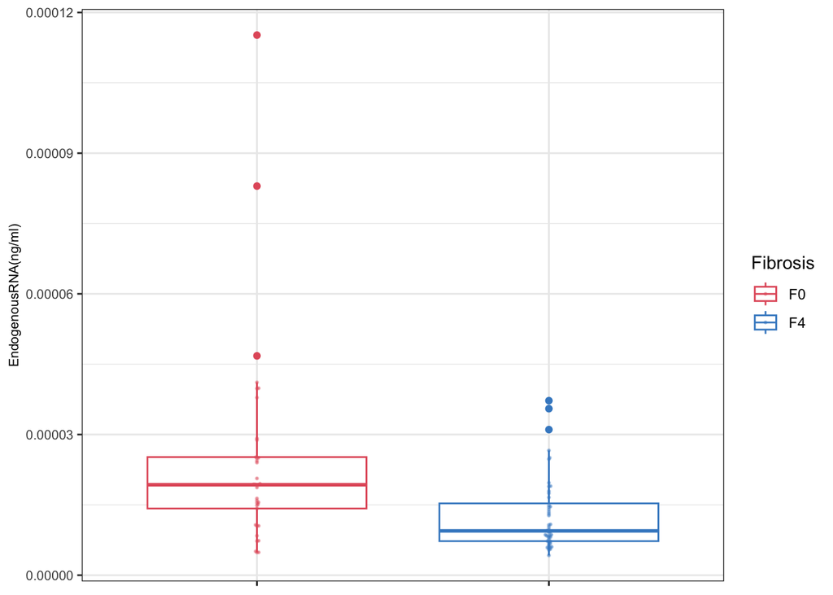

```r
fib_plt1 <- data %>%  ggplot(aes(x=Fibrosis, y=Endo_conc, color=Fibrosis)) +geom_boxplot() +
  geom_beeswarm(alpha=0.3, size = 0.05, dodge.width = 0.8, cex = 0.3) + scale_color_manual(values = color_panel)+
  geom_beeswarm(alpha=0.3, size = 0.5, dodge.width = 0.8, cex = 0.3) +
    theme_bw() + theme_final + ylab("EndogenousRNA(ng/ml)")

fib_plt1
```